# 03-exercises

Your Name Here

April 20, 2016

## Readings

*APM*

- Chapter 4 “Over Fitting and Model Tuning”
- Chapter 12.2 “Logisitic Regression”"

## Miscellaneous

I am still struggling with names …

- Please send me your picture

## Assignment

Note: The following will set-up your environment for this exercise. If you get an error stating that the packages have not been found, you need to install those packages.

## StepAIC

Using Fuel Economy data set from the **AppliedPredictiveModeling** Package. - fit the simplest possible model using lm - Use MASS::StepAIC to improve the model using forward stepwise regression - Fit the “full” model using lm - USe MASS::StepAIC to improve the model using backward stepwise regression

```r
 # Your work here
 fit.min <- lm( FE ~ 1, fe )


 stepAIC( fit.min, scope = ~ 1, direction = "backward")
```

```
## Start:  AIC=6054.49
## FE ~ 1
```

```
##
## Call:
## lm(formula = FE ~ 1, data = fe)
##
## Coefficients:
## (Intercept)
##       35.04
```

```r
 fit.full <- lm( FE ~ ., fe )
 step.back <- stepAIC( fit.full, score = ~ 1, direction = "backward")
```

```
## Start:  AIC=3665.22
## FE ~ EngDispl + NumCyl + Transmission + AirAspirationMethod +
##     NumGears + TransLockup + TransCreeperGear + DriveDesc + IntakeValvePerCyl +
##     ExhaustValvesPerCyl + CarlineClassDesc + VarValveTiming +
##     VarValveLift
##
##                       Df Sum of Sq   RSS    AIC
## - VarValveTiming       1       6.9 17080 3663.8
## - IntakeValvePerCyl    1      16.4 17090 3664.6
## - TransCreeperGear     1      18.4 17092 3664.8
## <none>                             17073 3665.2
## - ExhaustValvesPerCyl  1      24.6 17098 3665.3
## - AirAspirationMethod  2      53.3 17126 3665.7
## - NumGears             1      37.3 17111 3666.4
## - TransLockup          1      78.0 17151 3669.8
## - VarValveLift         1     170.6 17244 3677.6
## - NumCyl               1     677.8 17751 3719.6
## - EngDispl             1    1341.9 18415 3772.7
## - Transmission        15    1928.4 19002 3790.1
## - DriveDesc            4    3309.4 20383 3913.6
## - CarlineClassDesc    16    5165.9 22239 4015.7
##
## Step:  AIC=3663.81
## FE ~ EngDispl + NumCyl + Transmission + AirAspirationMethod +
##     NumGears + TransLockup + TransCreeperGear + DriveDesc + IntakeValvePerCyl +
##     ExhaustValvesPerCyl + CarlineClassDesc + VarValveLift
##
##                       Df Sum of Sq   RSS    AIC
## - IntakeValvePerCyl    1      16.8 17097 3663.2
## - ExhaustValvesPerCyl  1      22.4 17103 3663.7
## <none>                             17080 3663.8
## - TransCreeperGear     1      24.2 17104 3663.9
## - AirAspirationMethod  2      55.0 17135 3664.5
## - NumGears             1      37.3 17117 3665.0
## - TransLockup          1      77.4 17158 3668.3
## - VarValveLift         1     168.6 17249 3676.0
## - NumCyl               1     674.4 17754 3717.8
## - EngDispl             1    1343.0 18423 3771.3
## - Transmission        15    2079.5 19160 3800.0
## - DriveDesc            4    3347.2 20427 3914.8
## - CarlineClassDesc    16    5173.6 22254 4014.7
##
## Step:  AIC=3663.23
## FE ~ EngDispl + NumCyl + Transmission + AirAspirationMethod +
##     NumGears + TransLockup + TransCreeperGear + DriveDesc + ExhaustValvesPerCyl +
##     CarlineClassDesc + VarValveLift
##
##                       Df Sum of Sq   RSS    AIC
## <none>                             17097 3663.2
## - TransCreeperGear     1      31.8 17129 3663.9
## - NumGears             1      37.0 17134 3664.4
## - AirAspirationMethod  2      65.0 17162 3664.7
## - TransLockup          1      79.0 17176 3667.9
## - VarValveLift         1     165.2 17262 3675.1
## - ExhaustValvesPerCyl  1     298.0 17395 3686.2
## - NumCyl               1     807.0 17904 3728.0
## - EngDispl             1    1350.5 18447 3771.2
## - Transmission        15    2071.8 19169 3798.7
## - DriveDesc            4    3345.1 20442 3913.8
## - CarlineClassDesc    16    5157.7 22255 4012.7
```

```r
step.forw <-  stepAIC( fit.full, score = ~ 1, direction = "forward")
```

```
## Start:  AIC=3665.22
## FE ~ EngDispl + NumCyl + Transmission + AirAspirationMethod +
##     NumGears + TransLockup + TransCreeperGear + DriveDesc + IntakeValvePerCyl +
##     ExhaustValvesPerCyl + CarlineClassDesc + VarValveTiming +
##     VarValveLift
```

- Are they the same model? If not why? Which is better? JUstify your answer.

They not the same model. Step backward reduced the predictors, with optimal performance.

## Logsitic and Inverse Logistic Transformation

- Write an R function for the logistic function. The function should accept a `numeric` vector with values `[-Inf,Inf]` and produce a numeric vector in the the range `[0,1]`.
- Plot the logistic function from `[-10,10]`
- Write a R function for the inverse logistic function. The function should accept a `numeric` vector with values `[0,1]` and prodcuce a numeric vector in the range `[-Inf,Inf]`
- Plot the Inverse Logistic function from `[0,1]`

**Hint:** For plotting curves see `?graphics::curve` or `?ggplot2::stat_function`

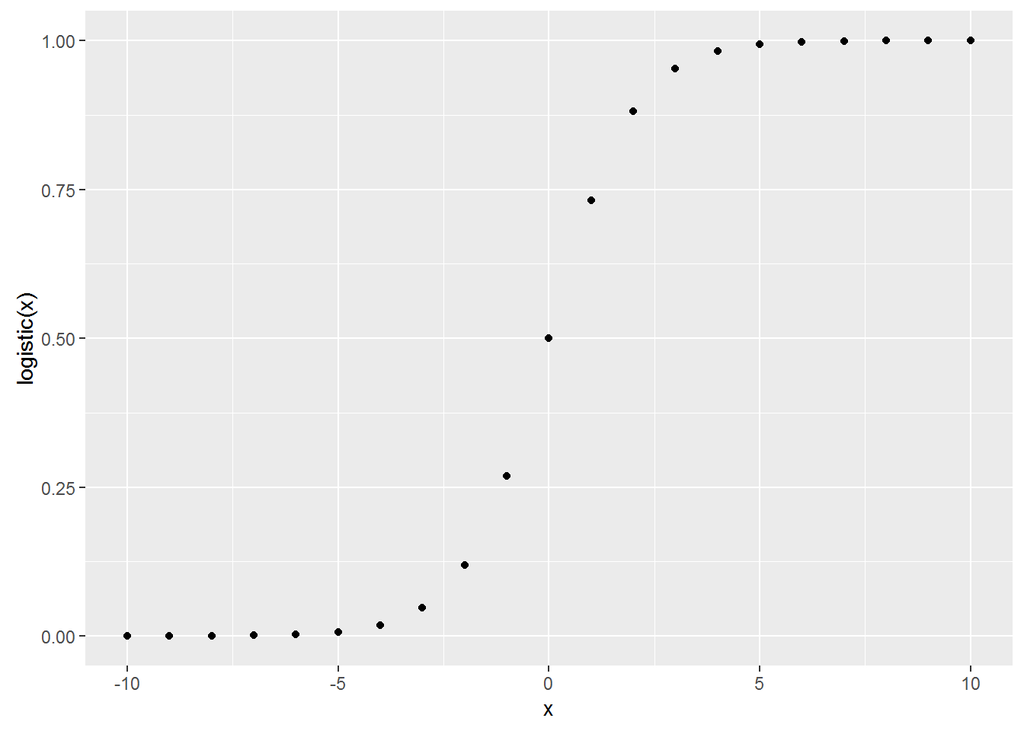

```r
logistic <- function(x) {
   # Your work here
  y <- exp(x)/(1+exp(x))
  return(y)
}
x<- -10:10
qplot(x,logistic(x))
```

```r
logistic_inv <- function(y) {
   # Your work

  log((y)/(1-y))
}

y<- 0:1
##qplot(y,logistic_inv(y))
```

**NOTE“** These functions are quite handy, in evaluating logistic regression results. You may want to save these functions in your own package.

```r
# DO NOT EDIT
c(-Inf,0,Inf) %>% logistic
```

```
## [1] 0.0 0.5 NaN
```

```r
c(0,0.5,1) %>% logistic_inv
```

```
## [1] -Inf    0  Inf
```

## German Credit Model

Using the GermanCredit data from the **Caret** package/ UCI Machine Learning Library, create a model for `Class` (“Good” vs. “Bad” ). Show your model performance.

```r
fit.min.forward <- glm(formula=GermanCredit$Class ~ ., family=binomial,data=GermanCredit)
fit.min.forward
```

```
##
## Call:  glm(formula = GermanCredit$Class ~ ., family = binomial, data = GermanCredit)
##
## Coefficients:
##                            (Intercept)
##                              8.3408096
##                               Duration
##                             -0.0278633
##                                 Amount
##                             -0.0001283
##              InstallmentRatePercentage
##                             -0.3300898
##                      ResidenceDuration
##                             -0.0047761
##                                    Age
##                              0.0145355
##                  NumberExistingCredits
##                             -0.2720759
##                NumberPeopleMaintenance
##                             -0.2646714
##                              Telephone
##                             -0.3000080
##                          ForeignWorker
##                             -1.3922159
##             CheckingAccountStatus.lt.0
##                             -1.7118880
##         CheckingAccountStatus.0.to.200
##                             -1.3370346
##           CheckingAccountStatus.gt.200
##                             -0.7462111
##             CheckingAccountStatus.none
##                                     NA
##         CreditHistory.NoCredit.AllPaid
##                             -1.4357716
##         CreditHistory.ThisBank.AllPaid
##                             -1.5791493
##                 CreditHistory.PaidDuly
##                             -0.8496580
##                    CreditHistory.Delay
##                             -0.5826102
```

[output cut: 77 more lines]

```
##                             -0.2402392
##                        Housing.ForFree
##                                     NA
##                Job.UnemployedUnskilled
##                              0.4794752
##                  Job.UnskilledResident
##                             -0.0566551
##                    Job.SkilledEmployee
##                             -0.0752423
## Job.Management.SelfEmp.HighlyQualified
##                                     NA
##
## Degrees of Freedom: 999 Total (i.e. Null);  951 Residual
## Null Deviance:       1222
## Residual Deviance: 895.8     AIC: 993.8
```

## Iterative Correlated Feature Removal

- Implement Kuhn’s iterative feature removal function described in **APM** Section 3.5, page 47

## Synthetic Data (Optional)

- x1: a normally distributed variable with `mean = 20` and standard deviation = 20 (`sd=8`).
- x2: a log-normally distributed feature with `meanlog = 1`, `sdlog=1.2`
- x3: a uniformly distributed feature with `min=0` and `max=50`.

```r
nsamples = 20

x1 <- rnorm(nsamples,20,20)
x2 <- rlnorm(nsamples, meanlog=1, sdlog = 1.2)
x3 <- runif(nsamples,0,50)
```

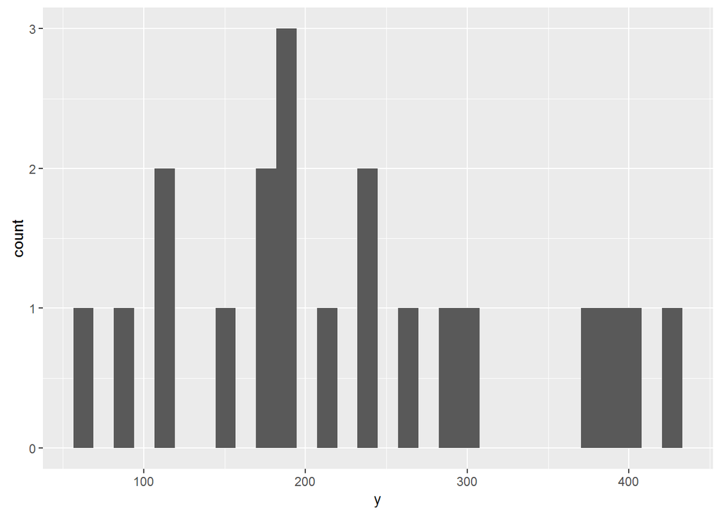

```r
beta0 <- rnorm(nsamples,0,15)  # intercept!
beta1 <- 2.3
beta2 <- 4
beta3 <- 7

betas <- matrix( c(2.5, 4, 7), nrow=1  )  # 1x4 matrix

# x0 <- rep(1,nsamples)

X  <- cbind(x1,x2,x3)  # 1000x4

y <- betas %*% t(X) %>% t
y <- y + beta0

qplot(y)
```

```r
dat <- data.frame(y,X)

fit <- lm( y ~ . , dat )

coef(fit)
```

```
## (Intercept)          x1          x2          x3
##   -9.695237    2.665614    4.455034    7.033101
```

```r
fit
```

```
##
## Call:
## lm(formula = y ~ ., data = dat)
##
## Coefficients:
## (Intercept)           x1           x2           x3
##      -9.695        2.666        4.455        7.033
```

- Did you recover the betas?
- Is the model good?
- What happens if increase the value of `nsamples`? Decrease it?
- What transformations would you apply to x1? x2? x3?